# Opaka Length Comp Investigations

Meg Oshima

5/21/2021

## Camera Lengths

```
##        X              PSU          DROP_CD           SPECIES_CD
##  Min.   :  1.0   Min.   :   18   Length:976         Length:976
##  1st Qu.:244.8   1st Qu.: 8961   Class :character   Class :character
##  Median :488.5   Median :23017   Mode  :character   Mode  :character
##  Mean   :488.5   Mean   :21961
##  3rd Qu.:732.2   3rd Qu.:35943
##  Max.   :976.0   Max.   :45499
##  SCIENTIFIC_NAME    COMMON_NAME           BFISH           OFFICIAL_DEPTH_M
##  Length:976         Length:976         Length:976         Min.   : 77.16
##  Class :character   Class :character   Class :character   1st Qu.:114.76
##  Mode  :character   Mode  :character   Mode  :character   Median :152.00
##                                                           Mean   :155.41
##                                                           3rd Qu.:192.00
##                                                           Max.   :274.00
##    LENGTH_CM         Island
##  Min.   :  5.40   Length:976
##  1st Qu.: 25.73   Class :character
##  Median : 37.34   Mode  :character
##  Mean   : 38.30
##  3rd Qu.: 51.73
##  Max.   :111.60
```

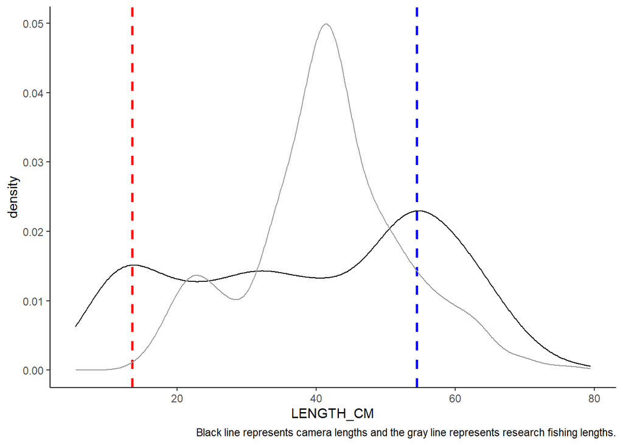

#### What is causing the mode in the smaller size classes in the BFISH camera data?

- Which sites are most of these samples coming from?
- Which islands are these samples from?
- What depth are these samples from?
- Which strata(s) are these samples from?

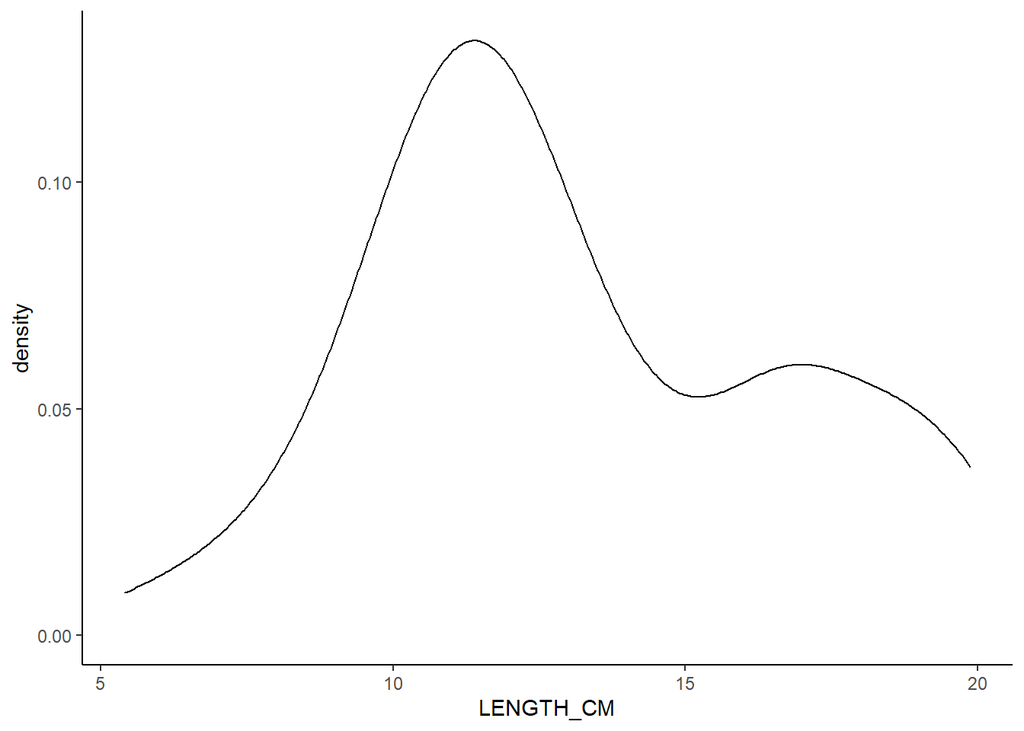

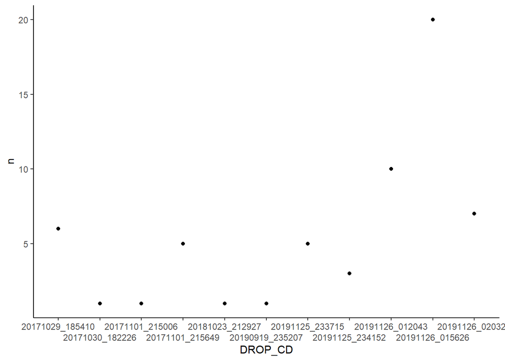

The number of Opaka between 10 and 15 cm that were caught at sites with at least one fish in that size bin.

Sites that caught 5 or more Opaka between 10 and 15 cm

| DROP_CD | STRATA | n |
| --- | --- | --- |
| 20191126_015626 | HB_H_S | 20 |
| 20191126_012043 | HB_H_S | 10 |
| 20191126_020320 | HB_H_S | 7 |
| 20171029_185410 | SB_A_S | 6 |
| 20171101_215649 | HB_L_S | 5 |
| 20191125_233715 | HB_H_S | 5 |

*Strata types are coded as hardness (HB = Hardbottom, SB = Softbottom), slope (H = High, L = Low, A = All), and depth (S = Shallow (75-200m), M = Medium (200-300m), D = Deep (300-400m)).*

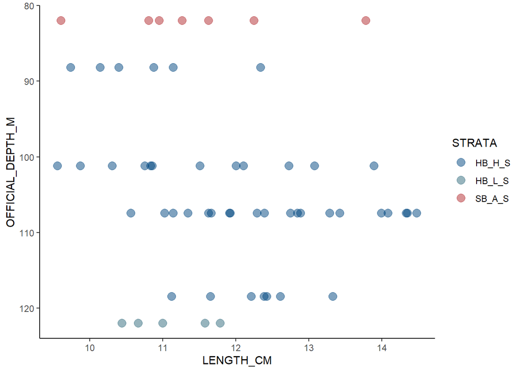

#### What is causing the mode in the larger size classes in the BFISH camera data?

- Which sites are most of these samples coming from?
- Which islands are these samples from?
- What depth are these samples from?
- Which strata(s) are these samples from?

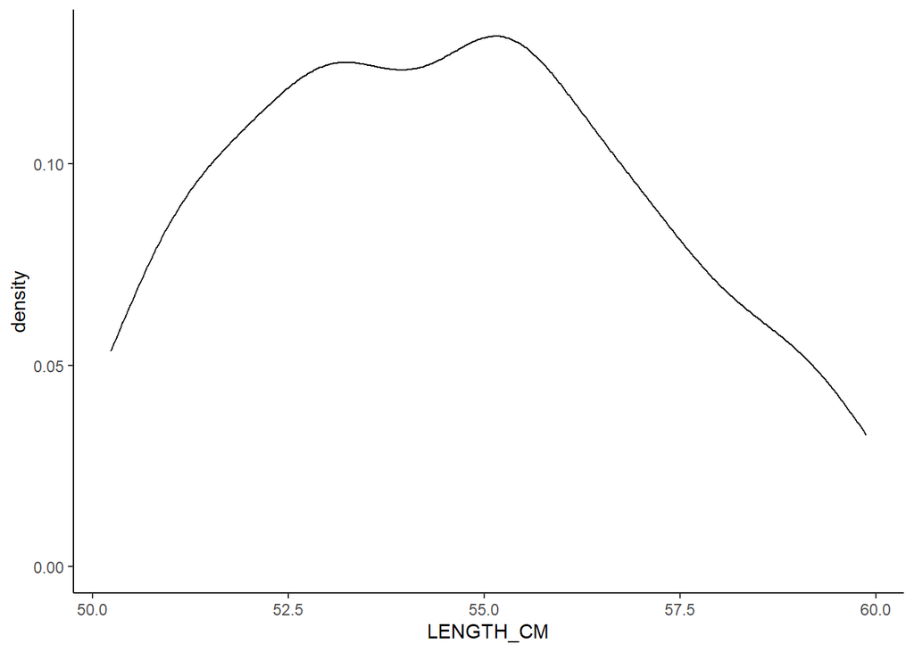

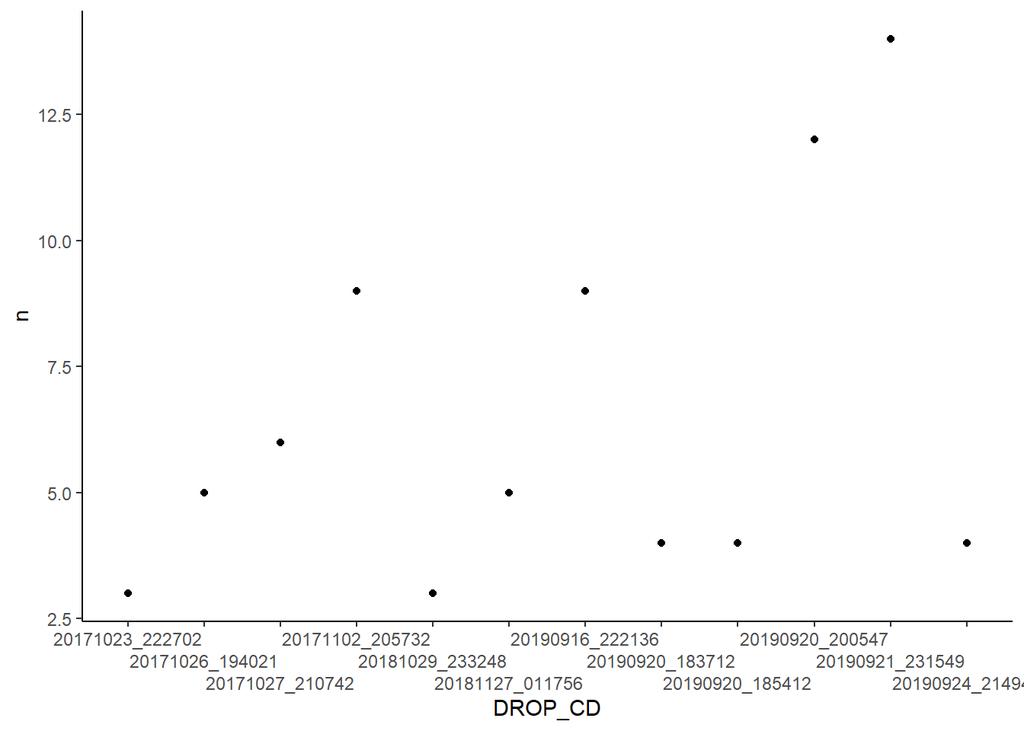

The number of Opaka between 50 and 60 cm caught at sites with more than n = 2 fish of that size.

Sites that caught more than 5 fish between 50 and 60 cm

| DROP_CD | STRATA | n |
| --- | --- | --- |
| 20190921_231549 | HB_H_S | 14 |
| 20190920_200547 | HB_H_S | 12 |
| 20171102_205732 | HB_H_M | 9 |
| 20190916_222136 | HB_H_S | 9 |
| 20171027_210742 | HB_H_M | 6 |

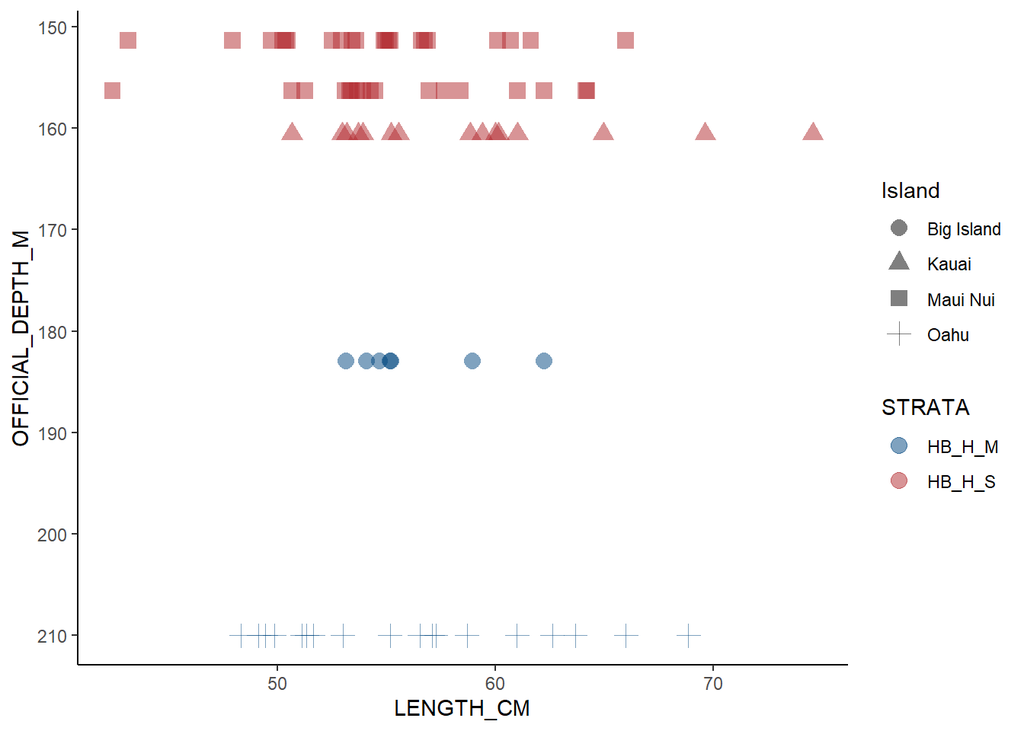

5 camera drops had more than 5 fish between 50 and 60 cm. The samples came from the Big Island (n = 1), Kauai (n = 1), Maui Nui (n = 2), and Oahu (n =1) were caught at depths of 150 to 210 m. Three samples were in a hardbottom, high-slope, shallow strata and two samples were in a hardbottom, high-slope, medium depth strata. The two highest catches occurred in 2019, and all occurred in 2019 or 2017.

## Fishing Lengths

```
##       PSU         SAMPLE_ID          SPECIES_CD        SCIENTIFIC_NAME
##  Min.   :  271   Length:292         Length:292         Length:292
##  1st Qu.:11839   Class :character   Class :character   Class :character
##  Median :16916   Mode  :character   Mode  :character   Mode  :character
##  Mean   :19669
##  3rd Qu.:32422
##  Max.   :43397
##
##  COMMON_NAME          LENGTH_CM       WEIGHT_LB        BFISH
##  Length:292         Min.   :16.00   Min.   :0.000   Length:292
##  Class :character   1st Qu.:35.50   1st Qu.:1.408   Class :character
##  Mode  :character   Median :41.50   Median :2.546   Mode  :character
##                     Mean   :41.42   Mean   :3.300
##                     3rd Qu.:47.75   3rd Qu.:4.877
##                     Max.   :76.00   Max.   :9.900
##                     NA's   :1       NA's   :252
##  SAMPLE_MEAN_DEPTH_M    Island             lat_deg         lon_deg
##  Min.   : 79.0       Length:292         Min.   :18.95   Min.   :-160.2
##  1st Qu.:116.0       Class :character   1st Qu.:20.59   1st Qu.:-156.9
##  Median :137.0       Mode  :character   Median :20.78   Median :-156.7
##  Mean   :138.9                          Mean   :20.73   Mean   :-156.7
##  3rd Qu.:158.0                          3rd Qu.:21.20   3rd Qu.:-156.5
##  Max.   :230.1                          Max.   :22.03   Max.   :-154.9
##
##     STRATA          Depth_MEDIAN_m  Depth_MAJORITY_m
##  Length:292         Min.   : 81.0   Min.   :  7.0
##  Class :character   1st Qu.:124.0   1st Qu.:107.0
##  Mode  :character   Median :157.0   Median :141.0
##                     Mean   :153.7   Mean   :141.1
##                     3rd Qu.:165.0   3rd Qu.:157.2
##                     Max.   :266.0   Max.   :372.0
##
```

Fishing events where more than 1 Opaka between 20 and 25 cm were caught

| SAMPLE_ID | STRATA | n |
| --- | --- | --- |
| 201708310930LANA | HB_H_S | 5 |
| 201708310749LANA | HB_H_S | 4 |
| 201910060752JOMO | HB_H_S | 4 |
| 201709101027ROMO | HB_H_S | 3 |

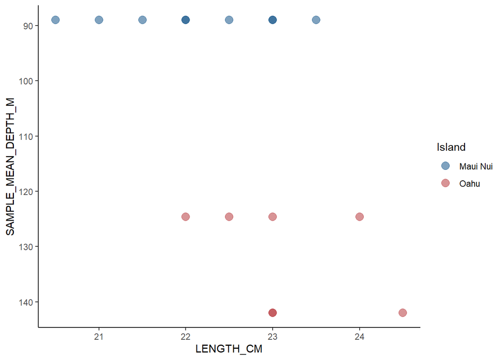

## Camera Lengths by Year, Strata, and Island

- 4 Years
  - 2016
  - 2017
  - 2018
  - 2019
- 5 Islands
  - Big Island
  - Maui Nui
  - Oahu
  - Ni’ihau
  - Kauai
- 10 strata
  - HB_H_D
  - HB_H_M
  - HB_H_S
  - HB_L_S
  - SB_A_S
  - HB_L_D
  - SB_A_D
  - HB_L_M
  - SB_A_M
  - SB_H_S

Number of Camera Drops per Year

| Year | n |
| --- | --- |
| 2016 | 15 |
| 2017 | 38 |
| 2018 | 36 |
| 2019 | 42 |

#### Density Plot by Year

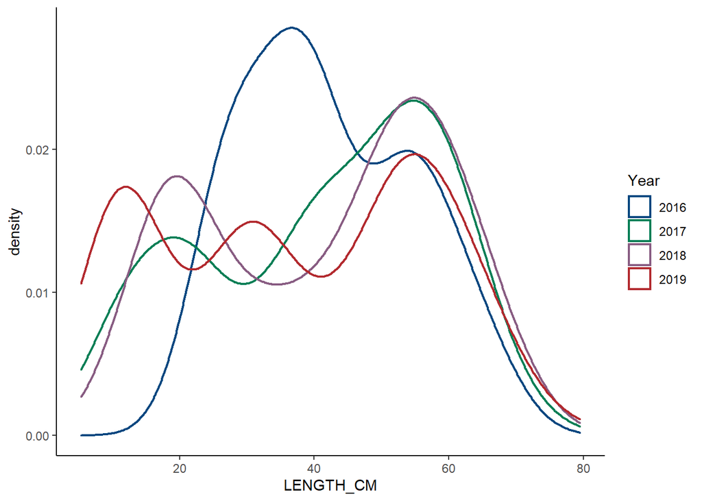

- All years have a bimodal (or tri) distribution, but small modes differ.
- 2019 has three modes, with middle one being the smallest.
- 2017 and 2018 are very similar to each other and 2016 is the most distinct from the other years.

Summary of Camera Drops per Strata

| Strata | N | Mean Length (SD) | Median Length |
| --- | --- | --- | --- |
| HB_H_S | 85 | 37.92 (18.11) | 36.24 |
| HB_H_M | 30 | 55.02 (7.45) | 55.17 |
| HB_L_S | 7 | 39.62 (17.54) | 42.74 |
| SB_A_S | 6 | 15.86 (3.3) | 16.49 |
| HB_L_M | 3 | 56.25 (8.09) | 55.10 |

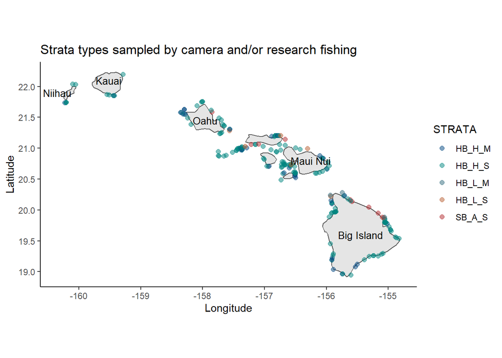

#### Density Plot by Strata

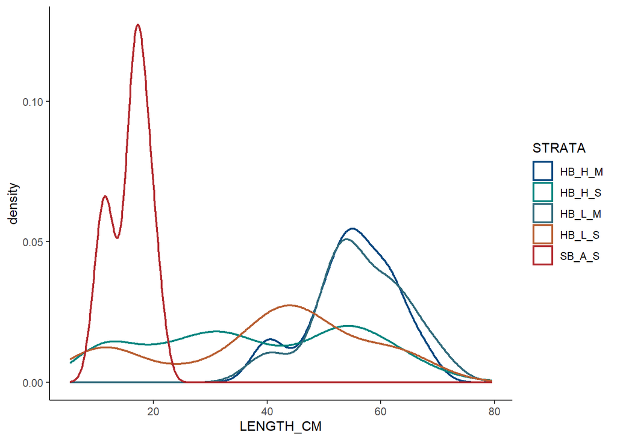

Softbottom sites have only small Opaka (approx. < 20 cm) and the hardbottom, medium depth sites have mostly larger Opaka (> 45cm).

Based on this figure, it seems that depth is the common factor for small Opaka; they were never found in the medium depth strata, only the shallow depths. However, smaller amounts of large Opaka (~55 cm) were found in shallow strata as well so those strata are not exclusively small Opaka. The slope and bottom-hardness varied (low, high, and all, and soft and hard). Softbottom strata had relatively much more smaller (< 20cm) Opaka (n = 27 out of 29 [93%]) than the hardbottom strata (n = 6 out of 29 [20.7%] and n = 81 out of 394 [20.6%] respectively).

Number of Camera Drops per Island

| Island | n |
| --- | --- |
| Maui Nui | 53 |
| Big Island | 48 |
| Oahu | 21 |
| Niihau | 5 |
| Kauai | 4 |

#### Density Plot by Island

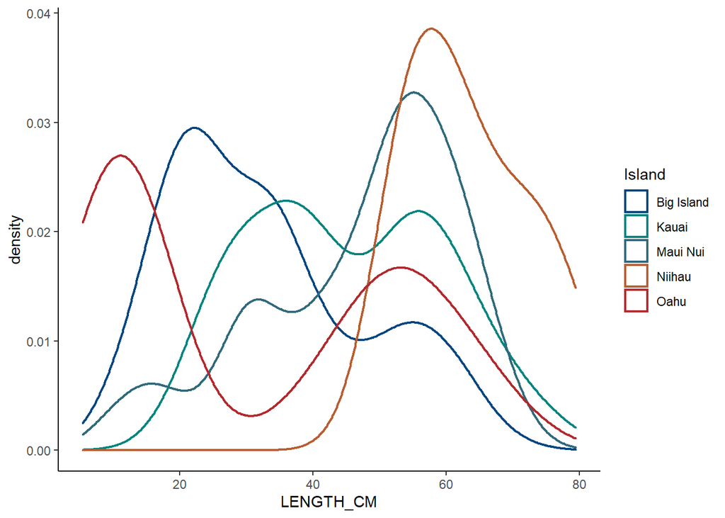

- Big Island and Oahu have more smaller fish and less bigger fish than the other islands.
- Niihau only had larger fish.
- Kauai had an almost even split between smaller and larger fish (with bigger small fish so less of a difference between modes).

### Strata-Year Interactions

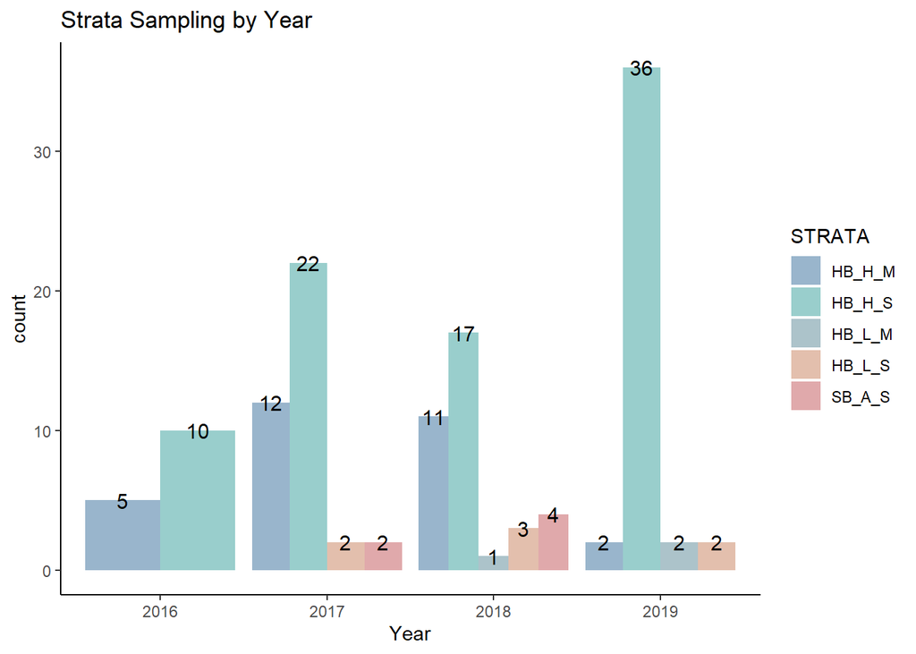

Softbottom areas were only sampled in 2017 (n = 2) and 2018 (n = 4). High-sloped, shallow, hardbottom areas were most frequently sampled strata type, followed by high-sloped, mid-depth, hardbottom areas.

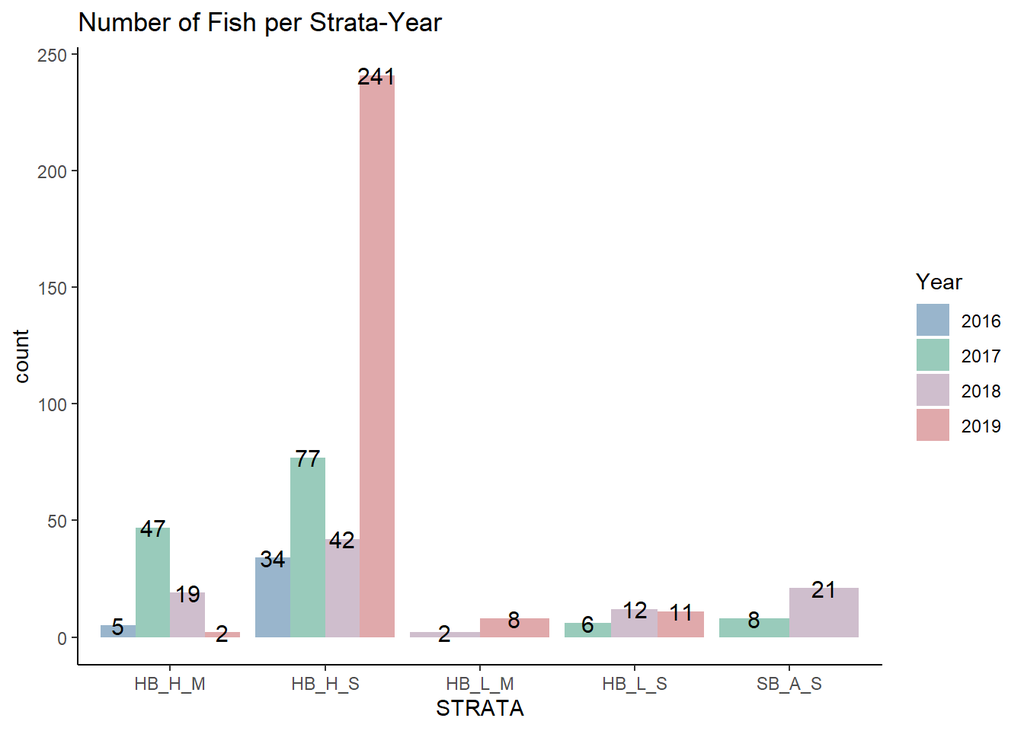

#### Density Plot by Strata and Year

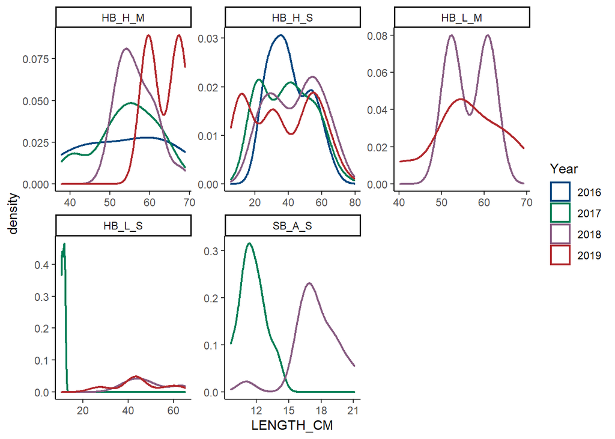

- Density plot for HB_H_S looks very similar to the length frequencies by year figure
- SB_A_S had small fish (mode ~12 and ~18 cm) in 2017 and 2018
- In 2017, 6 Opaka were caught at HB_L_S that were between 10 - 12 cm. They were all from the same PSU

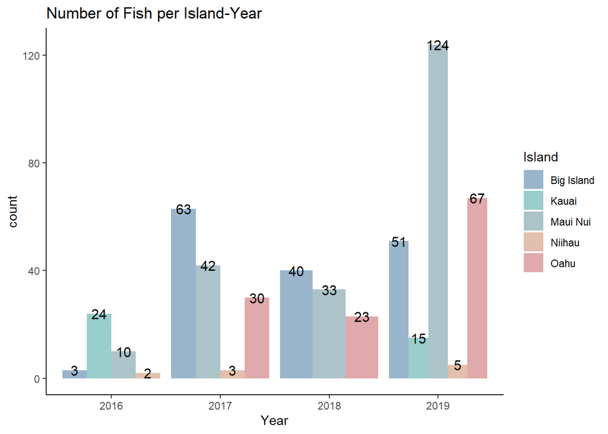

#### Density Plot by Island and Year

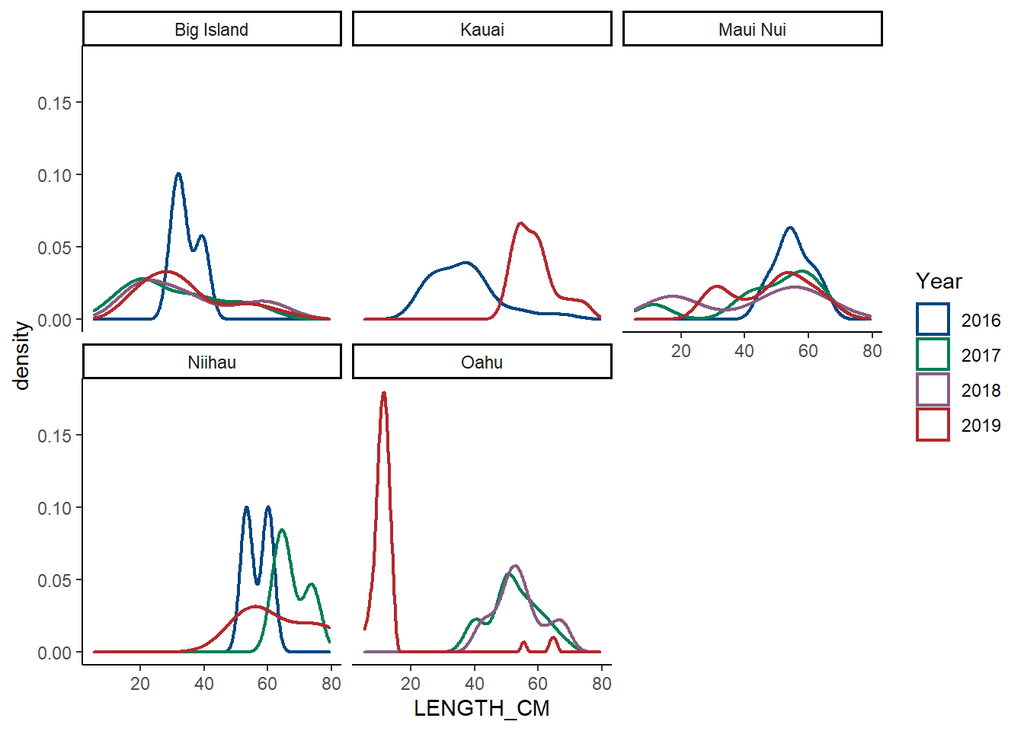

- In the Big Island, catches were pretty consistent between 2017-2019 but 2016 was very different, probably because n = 3. Also, depth was more in the mid-range of sampled depths. They did not sample in the shallower range, unlike other years.
- Kauai only had 2 years of data (2016 n = 24, and 2019 n = 15) and the distributions were different, 2016 had mostly smaller fish whereas 2019 had more larger fish.
- Maui Nui catches all had the same mode for larger sizes (between 40 - 70 cm) but the modes for the smaller sized fish fluctuated each year.
- Niihau had very small sample sizes (n = 2 - 5) for the 3 years sampling occurred there so distributions are not that reliable but size range is fairly consistent. Also, the distributions are consistent with the 2019 lengths in Kauai (support for combining those regions?).
- Oahu had consistent length distributions for 2017 and 2018 but 2019 was almost exclusively small fish (< 20 cm, n = 67)

#### Density Plot by Year and Island

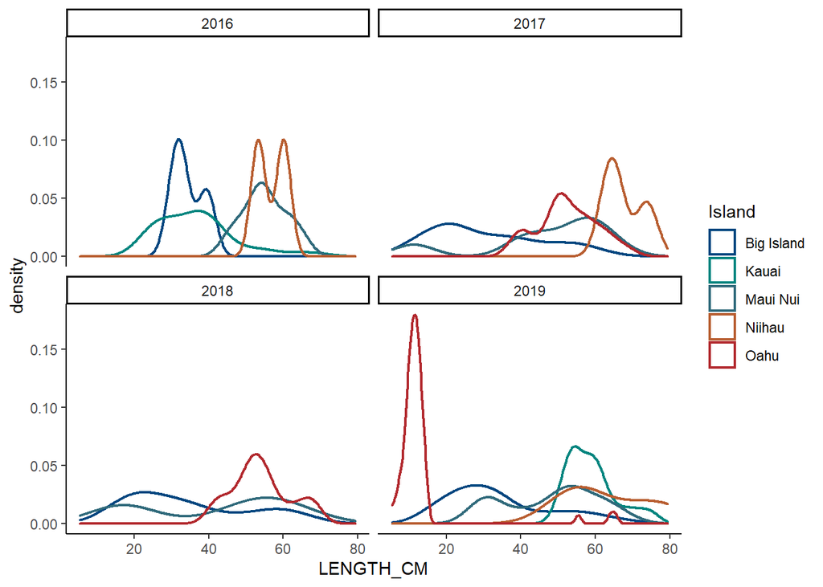

- In 2016, Big Island (n = 3) and Kauai (n = 24) were similar and Niiahu (n = 2) and Maui Nui (n = 10) were similar.
- In 2017, mostly smaller fish caught off Big Island compared to the other islands.
- In 2018, there is a bimodal distribution for Maui Nui and less pronouced for the Big Island. Oahu has only larger fish (> 40 cm).
- In 2019, the first mode is almost exclusively from Oahu samples, the second mode is from Big Island and Maui Nui samples, and the third mode is from all islands.

### Strata-Island Interactions

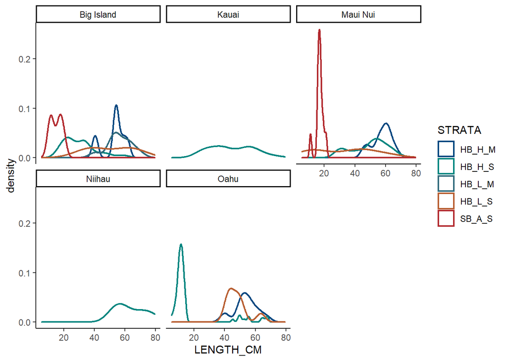

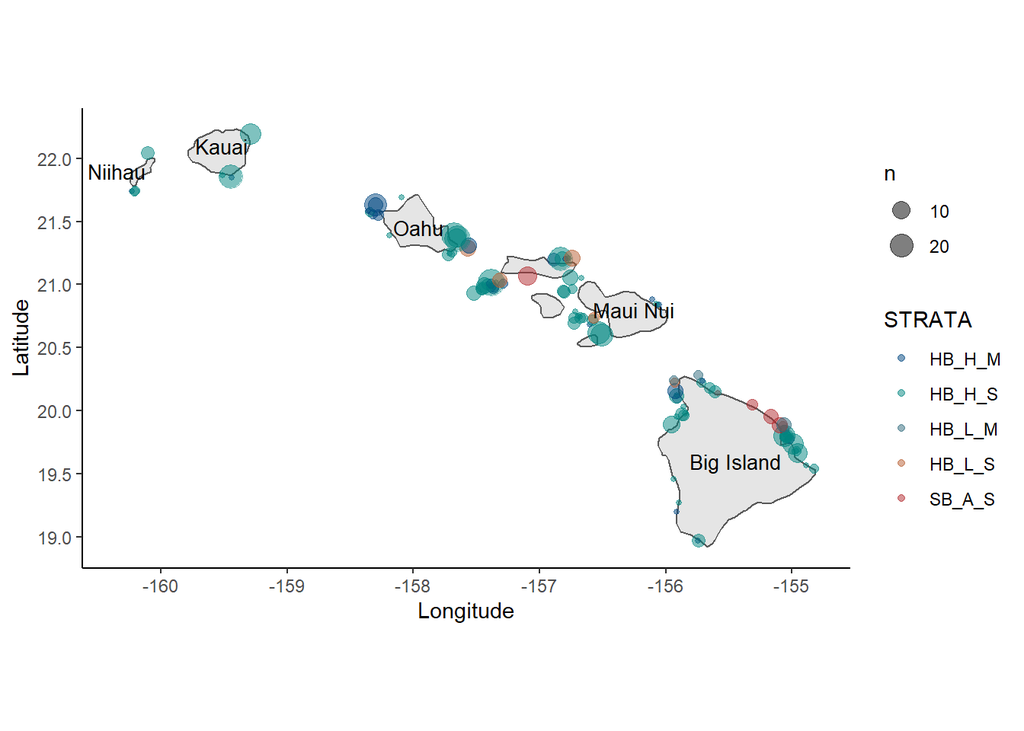

## Fishing Lengths by Year, Strata, and Island

Number of Fishing Events per Year

| Year | n |
| --- | --- |
| 2016 | 19 |
| 2017 | 33 |
| 2018 | 16 |
| 2019 | 18 |

#### Density Plot by Year

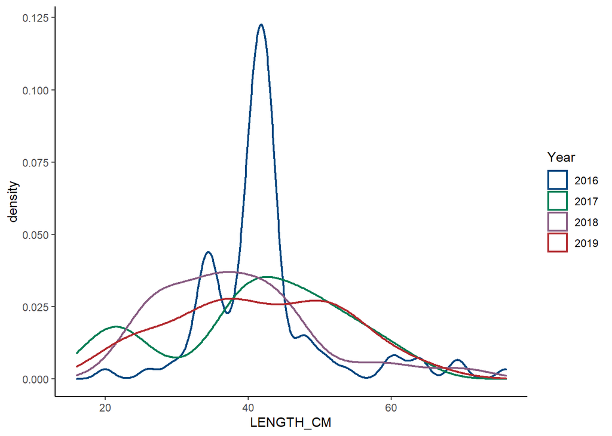

Number of Fishing Events per Strata

| STRATA | n |
| --- | --- |
| HB_H_M | 11 |
| HB_H_S | 69 |
| HB_L_M | 1 |
| HB_L_S | 1 |
| SB_A_S | 4 |

#### Density Plot by Strata

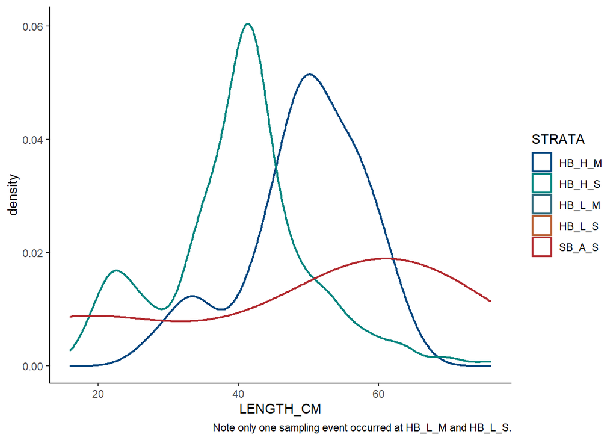

Number of Fishing Events per Island

| Island | n |
| --- | --- |
| Big Island | 21 |
| Kauai | 2 |
| Maui Nui | 51 |
| Niihau | 2 |
| Oahu | 10 |

#### Density Plot by Island

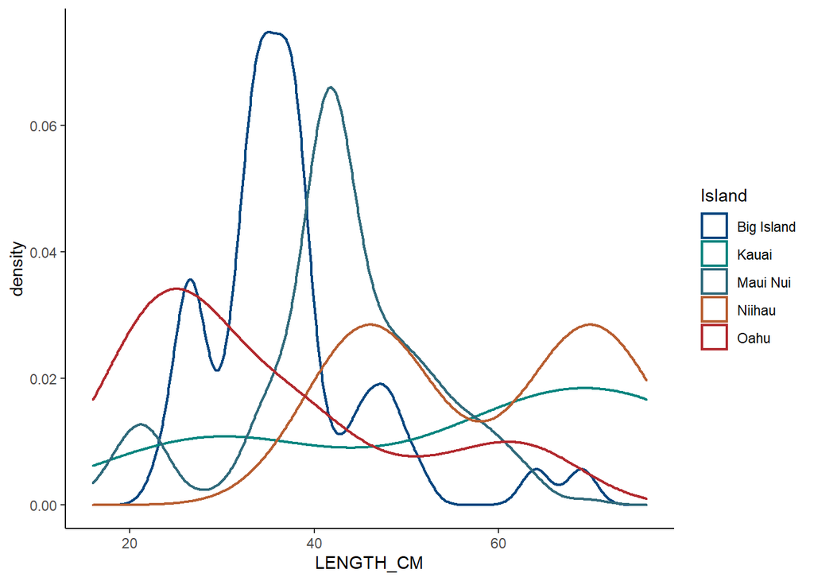

#### Number of Fish per Strata-Year

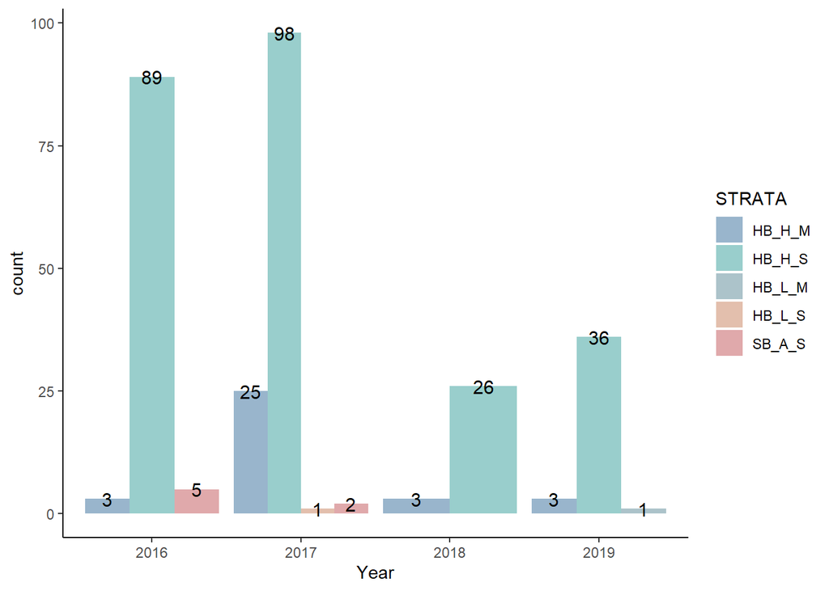

#### Number of Fish per Island-Year

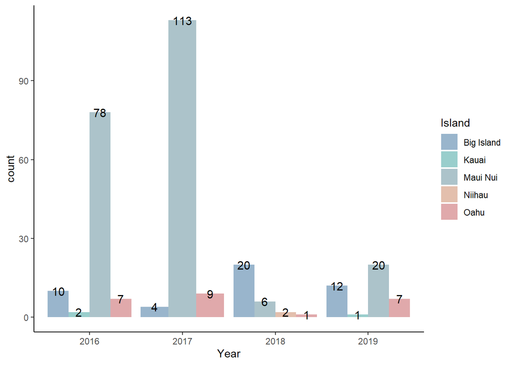

#### Density Plot by Island and Year

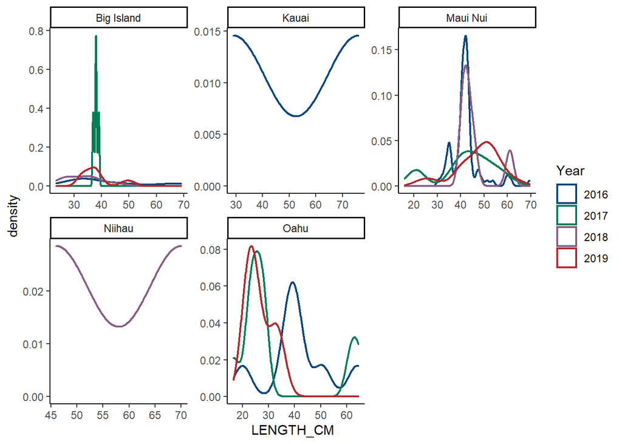

### Strata-Island Interactions

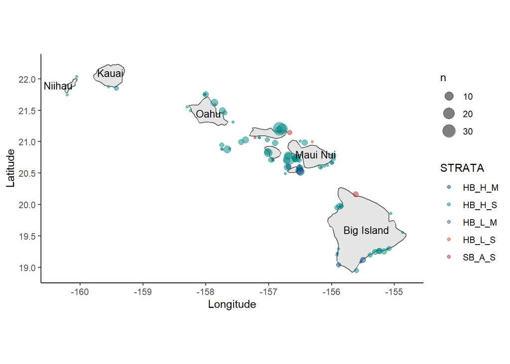

## Camera vs Research Fishing

#### Areas sampled by camera and research fishing

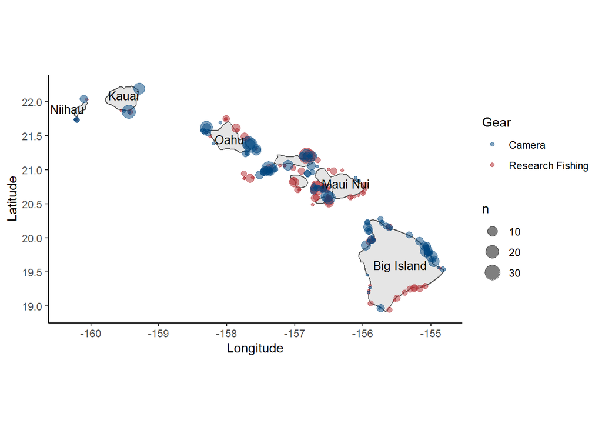

#### Depths Sampled by Gear

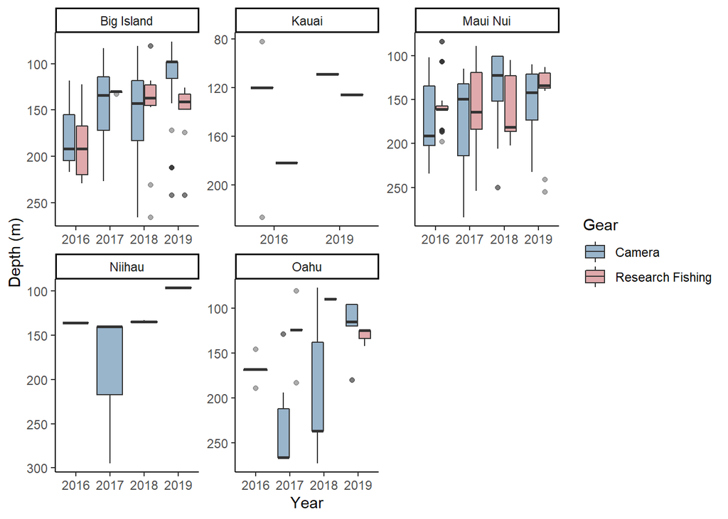

Median depth for each PSU was chosen to represent the overall depth of PSU to follow the strata determination methodology.

#### Length Composition Comparisons by Year

Number of Sampling Events by Year

| Year | Camera | Research Fishing |
| --- | --- | --- |
| 2016 | 15 | 19 |
| 2017 | 38 | 33 |
| 2018 | 36 | 16 |
| 2019 | 42 | 18 |

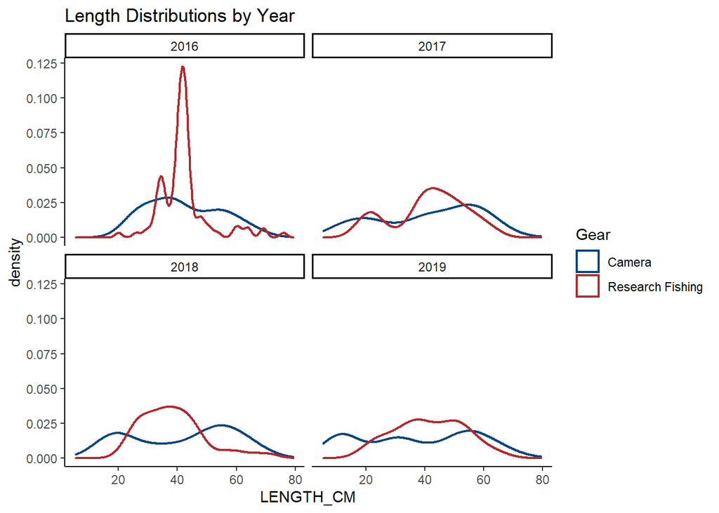

#### Length Composition Comparisons by Strata

Number of Sampling Events by Strata

| STRATA | Camera | Research Fishing |
| --- | --- | --- |
| HB_H_M | 30 | 11 |
| HB_H_S | 85 | 69 |
| HB_L_M | 3 | 1 |
| HB_L_S | 7 | 1 |
| SB_A_S | 6 | 4 |

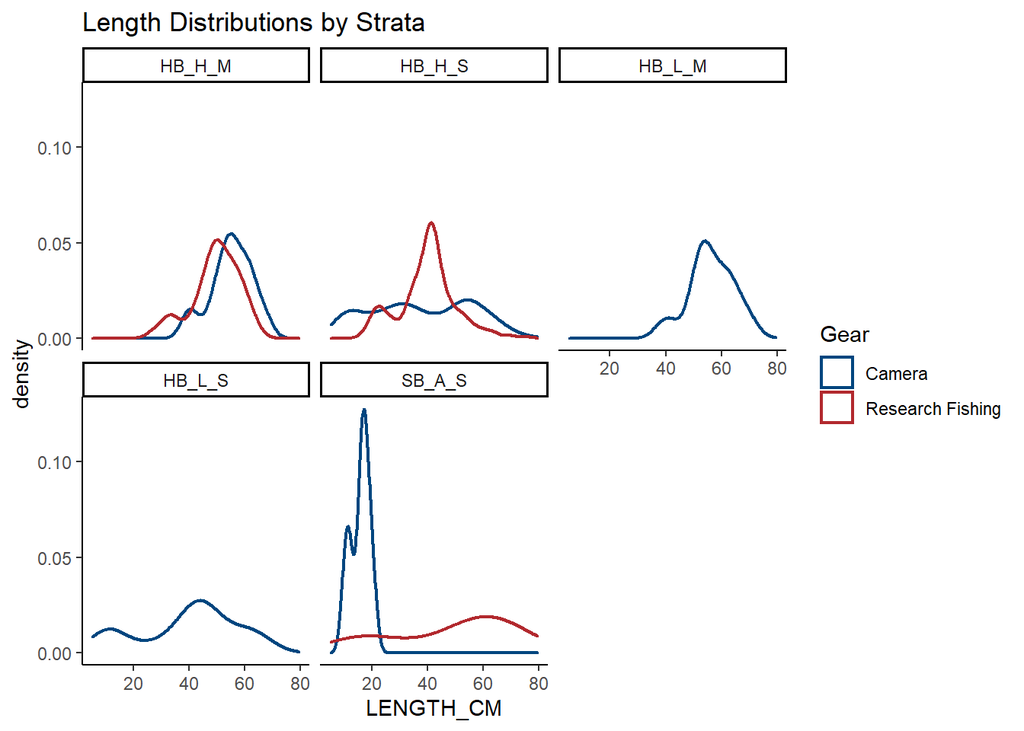